# APLICACION

Kelva Llanos

2025-02-27

# BASE DE DATOS: MUNDIALES

-seleccion: Nombre del país, tipo character

-continente: Continente al que pertenece el país, tipo character

-participaciones: cantidad de mundiales jugados, tipo numeric

-pg: cantidad de partidos ganados, tipo numeric

-pe: cantidad de partidos empatados, tipo numeric

-pp: cantidad de partidos perdidos, tipo numeric

-gf: cantidad de goles a favor, tipo numeric

-gc: cantidad de goles en contra, tipo numeric

-titulo: cantidad de mundiales ganadados, tipo numeric

Este archivo tiene 80 registros, ya que son 80 países los que han disputado algún mundial a lo largo de la historia. Los primeros registros lucen así:

```r
library(tidyverse)
datos <- read_delim("C:/Users/NATHALLY/Documents/PLE/datos/mundiales.csv",delim=",")
datos
```

| seleccion | continente | participaciones | pg | pe | pp | gf | gc | titulos |
| --- | --- | --- | --- | --- | --- | --- | --- | --- |
| Pais_1 | Asia | 13 | 38 | 27 | 0 | 63 | 0 | 2 |
| Pais_2 | Ocean\xeda | 9 | 5 | 24 | 16 | 0 | 24 | 3 |
| Pais_3 | \xc1frica | 15 | 7 | 24 | 44 | 16 | 62 | 1 |
| Pais_4 | Ocean\xeda | 13 | 26 | 22 | 17 | 43 | 21 | 2 |
| Pais_5 | Ocean\xeda | 1 | 0 | 2 | 3 | 0 | 9 | 4 |
| Pais_6 | Europa | 7 | 4 | 9 | 22 | 11 | 57 | 5 |
| Pais_7 | \xc1frica | 9 | 32 | 2 | 11 | 29 | 21 | 0 |
| Pais_8 | \xc1frica | 1 | 2 | 2 | 1 | 4 | 0 | 4 |
| Pais_9 | \xc1frica | 12 | 41 | 15 | 4 | 45 | 3 | 5 |
| Pais_10 | Ocean\xeda | 8 | 11 | 15 | 14 | 5 | 41 | 3 |

[output cut: 70 more lines]

## **Estructura de datos**

```r
#Muestra la estructura interna del dataset
str(datos)
```

```
## spc_tbl_ [80 × 9] (S3: spec_tbl_df/tbl_df/tbl/data.frame)
##  $ seleccion      : chr [1:80] "Pais_1" "Pais_2" "Pais_3" "Pais_4" ...
##  $ continente     : chr [1:80] "Asia" "Ocean\xeda" "\xc1frica" "Ocean\xeda" ...
##  $ participaciones: num [1:80] 13 9 15 13 1 7 9 1 12 8 ...
##  $ pg             : num [1:80] 38 5 7 26 0 4 32 2 41 11 ...
##  $ pe             : num [1:80] 27 24 24 22 2 9 2 2 15 15 ...
##  $ pp             : num [1:80] 0 16 44 17 3 22 11 1 4 14 ...
##  $ gf             : num [1:80] 63 0 16 43 0 11 29 4 45 5 ...
##  $ gc             : num [1:80] 0 24 62 21 9 57 21 0 3 41 ...
##  $ titulos        : num [1:80] 2 3 1 2 4 5 0 4 5 3 ...
##  - attr(*, "spec")=
##   .. cols(
##   ..   seleccion = col_character(),
##   ..   continente = col_character(),
##   ..   participaciones = col_double(),
##   ..   pg = col_double(),
##   ..   pe = col_double(),
##   ..   pp = col_double(),
##   ..   gf = col_double(),
##   ..   gc = col_double(),
##   ..   titulos = col_double()
##   .. )
##  - attr(*, "problems")=<externalptr>
```

### **Creación y Renombre de variables**

Vamos a calcular la cantitad total de partidos que cada selección ha jugado en los mundiales a lo largo de toda la historia (pj), sumando la cantidad de partidos que ha ganado, empatado y perdido:

```r
datos <- mutate(datos, pj = pg + pe + pp)
head(datos)
```

| seleccion | continente | participaciones | pg | pe | pp | gf | gc | titulos | pj |
| --- | --- | --- | --- | --- | --- | --- | --- | --- | --- |
| Pais_1 | Asia | 13 | 38 | 27 | 0 | 63 | 0 | 2 | 65 |
| Pais_2 | Ocean\xeda | 9 | 5 | 24 | 16 | 0 | 24 | 3 | 45 |
| Pais_3 | \xc1frica | 15 | 7 | 24 | 44 | 16 | 62 | 1 | 75 |
| Pais_4 | Ocean\xeda | 13 | 26 | 22 | 17 | 43 | 21 | 2 | 65 |
| Pais_5 | Ocean\xeda | 1 | 0 | 2 | 3 | 0 | 9 | 4 | 5 |
| Pais_6 | Europa | 7 | 4 | 9 | 22 | 11 | 57 | 5 | 35 |

Vamos a crear una nueva columna que se llame campeon y tenga el valor “campeón” cuando titulos > 0 y “no campeón” en caso contrario.

```r
datos <- mutate(datos, campeon = ifelse(titulos > 0, "campeón", "no campeón"))
head(datos)
```

| seleccion | continente | participaciones | pg | pe | pp | gf | gc | titulos | pj | campeon |
| --- | --- | --- | --- | --- | --- | --- | --- | --- | --- | --- |
| Pais_1 | Asia | 13 | 38 | 27 | 0 | 63 | 0 | 2 | 65 | campeón |
| Pais_2 | Ocean\xeda | 9 | 5 | 24 | 16 | 0 | 24 | 3 | 45 | campeón |
| Pais_3 | \xc1frica | 15 | 7 | 24 | 44 | 16 | 62 | 1 | 75 | campeón |
| Pais_4 | Ocean\xeda | 13 | 26 | 22 | 17 | 43 | 21 | 2 | 65 | campeón |
| Pais_5 | Ocean\xeda | 1 | 0 | 2 | 3 | 0 | 9 | 4 | 5 | campeón |
| Pais_6 | Europa | 7 | 4 | 9 | 22 | 11 | 57 | 5 | 35 | campeón |

Crear una nueva variable llamada puntos que indique cuál es el puntaje total obtenido por cada selección a lo largo del tiempo, teniendo en cuenta que cada partido ganado aporta 3 puntos, cada partido empatado aporta 1 punto y cada partido perdido aporta 0 puntos, y otra nueva variable llamada dg, diferencia de goles, definida como la resta entre los goles a favor y los goles en contra. Además, renombrar la variable (atributo) gf por goles_favor y gc por goles_contra

```r
datos <-
  datos %>%
  mutate(
        puntos = 3 * pg + pe,
    dg = gf - gc
  ) %>%
  rename(goles_favor = gf, goles_contra = gc)

head(datos)
```

| seleccion | continente | participaciones | pg | pe | pp | goles_favor | goles_contra | titulos | pj | campeon | puntos | dg |
| --- | --- | --- | --- | --- | --- | --- | --- | --- | --- | --- | --- | --- |
| Pais_1 | Asia | 13 | 38 | 27 | 0 | 63 | 0 | 2 | 65 | campeón | 141 | 63 |
| Pais_2 | Ocean\xeda | 9 | 5 | 24 | 16 | 0 | 24 | 3 | 45 | campeón | 39 | -24 |
| Pais_3 | \xc1frica | 15 | 7 | 24 | 44 | 16 | 62 | 1 | 75 | campeón | 45 | -46 |
| Pais_4 | Ocean\xeda | 13 | 26 | 22 | 17 | 43 | 21 | 2 | 65 | campeón | 100 | 22 |
| Pais_5 | Ocean\xeda | 1 | 0 | 2 | 3 | 0 | 9 | 4 | 5 | campeón | 2 | -9 |
| Pais_6 | Europa | 7 | 4 | 9 | 22 | 11 | 57 | 5 | 35 | campeón | 21 | -46 |

### **Recodificación de categorías**

Aquellos registros con “Ocean”, “1frica” y “Am9rica” en continente son reemplazados por “Oceanía”, “África” y “América” respectivamente. Los otros valores quedan como estaban:

```r
datos <- mutate(
  datos,
  continente = case_when(
    continente == "Ocean\xeda" ~ "Oceanía",
    continente == "\xc1frica" ~ "África",
    continente == "Am\xe9rica" ~ "América",
    TRUE ~ continente # opción por defecto
  )
)

head(datos)
```

| seleccion | continente | participaciones | pg | pe | pp | goles_favor | goles_contra | titulos | pj | campeon | puntos | dg |
| --- | --- | --- | --- | --- | --- | --- | --- | --- | --- | --- | --- | --- |
| Pais_1 | Asia | 13 | 38 | 27 | 0 | 63 | 0 | 2 | 65 | campeón | 141 | 63 |
| Pais_2 | Oceanía | 9 | 5 | 24 | 16 | 0 | 24 | 3 | 45 | campeón | 39 | -24 |
| Pais_3 | África | 15 | 7 | 24 | 44 | 16 | 62 | 1 | 75 | campeón | 45 | -46 |
| Pais_4 | Oceanía | 13 | 26 | 22 | 17 | 43 | 21 | 2 | 65 | campeón | 100 | 22 |
| Pais_5 | Oceanía | 1 | 0 | 2 | 3 | 0 | 9 | 4 | 5 | campeón | 2 | -9 |
| Pais_6 | Europa | 7 | 4 | 9 | 22 | 11 | 57 | 5 | 35 | campeón | 21 | -46 |

# ORGANIZACIÓN DE DATOS: Tablas de frecuencias y Gráficos Estadísticos

## **Tablas de frecuencias y Gráficos Estadísticos para variables cualitativas**

**Tabla de frecuencias**

```r
frecuencias <- datos %>%
  group_by(continente) %>%
  summarise(Frecuencia = n()) %>%
  mutate(Frecuencia_Relativa = Frecuencia / sum(Frecuencia),
         Frecuencia_Porcentual = Frecuencia_Relativa * 100)

frecuencias
```

| continente | Frecuencia | Frecuencia_Relativa | Frecuencia_Porcentual |
| --- | --- | --- | --- |
| América | 10 | 0.1250 | 12.50 |
| Asia | 25 | 0.3125 | 31.25 |
| Europa | 19 | 0.2375 | 23.75 |
| Oceanía | 15 | 0.1875 | 18.75 |
| África | 11 | 0.1375 | 13.75 |

**Gráficos de Barras y Sector Circular**

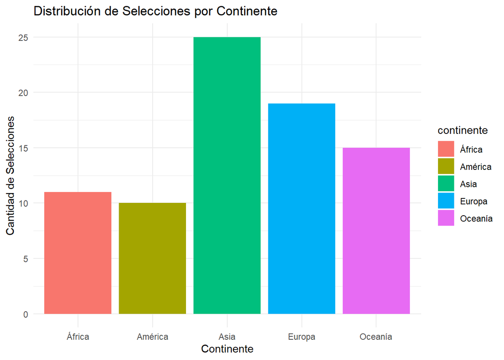

```r
# **Gráfico de barras**
grafico_barras <- ggplot(frecuencias, aes(x = continente, y = Frecuencia, fill = continente)) +
  geom_bar(stat = "identity") +
  theme_minimal() +
  labs(title = "Distribución de Selecciones por Continente", x = "Continente", y = "Cantidad de Selecciones")
# Mostrar gráfico de barras
print(grafico_barras)
```

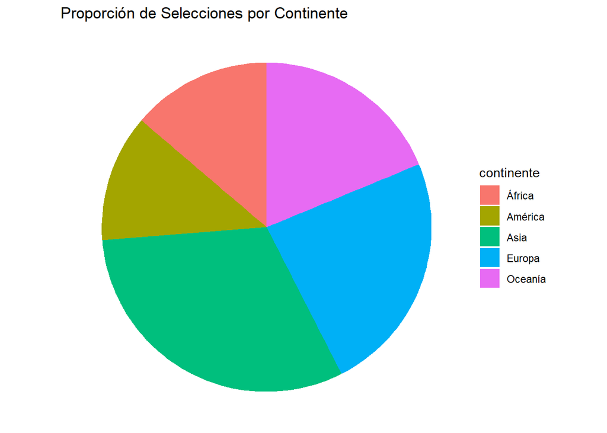

```r
# **Gráfico de sectores (pastel)**

grafico_pie <- ggplot(frecuencias, aes(x = "", y = Frecuencia, fill = continente)) +
  geom_bar(stat = "identity", width = 1) +
  coord_polar(theta = "y") +
  theme_void() +
  labs(title = "Proporción de Selecciones por Continente")
# Mostrar gráfico de sectores
print(grafico_pie)
```

## **Tablas de frecuencias y Gráficos Estadísticos para variable cuantitativa discreta**

**Tabla de frecuencias**

```r
frecuencias <- datos %>%
  group_by(participaciones) %>%
  summarise(Frecuencia = n()) %>%
  mutate(Frecuencia_Relativa = Frecuencia / sum(Frecuencia),
         Frecuencia_Porcentual = Frecuencia_Relativa * 100) %>%
  arrange(desc(Frecuencia)) %>%  # Ordenar de mayor a menor frecuencia
  mutate(Frecuencia_Acumulada = cumsum(Frecuencia),
         Frecuencia_Relativa_Acumulada = cumsum(Frecuencia_Relativa),
         Frecuencia_Porcentual_Acumulada = cumsum(Frecuencia_Porcentual))

# Mostrar la tabla de frecuencias con acumuladas
print(frecuencias)
```

```
## # A tibble: 21 × 7
##    participaciones Frecuencia Frecuencia_Relativa Frecuencia_Porcentual
##              <dbl>      <int>               <dbl>                 <dbl>
##  1               1          8              0.1                    10
##  2               7          8              0.1                    10
##  3               3          7              0.0875                  8.75
##  4              13          7              0.0875                  8.75
##  5               9          6              0.075                   7.5
##  6               5          5              0.0625                  6.25
##  7              12          5              0.0625                  6.25
##  8              15          5              0.0625                  6.25
##  9               8          4              0.05                    5
## 10              10          3              0.0375                  3.75
## # ℹ 11 more rows
## # ℹ 3 more variables: Frecuencia_Acumulada <int>,
## #   Frecuencia_Relativa_Acumulada <dbl>, Frecuencia_Porcentual_Acumulada <dbl>
```

**Gráfico de líneas o bastones**

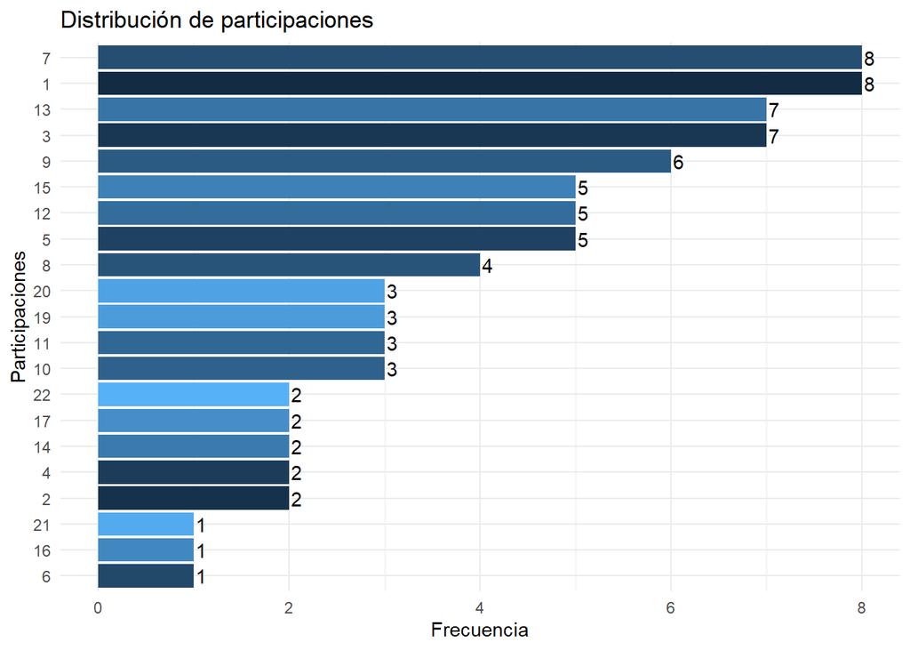

```r
# Crear el gráfico de listones
ggplot(frecuencias, aes(x = reorder(participaciones, Frecuencia), y = Frecuencia, fill = participaciones)) +
  geom_col() +
  coord_flip() +  # Gira el gráfico para que sea horizontal (listones)
  labs(title = "Distribución de participaciones",
       x = "Participaciones",
       y = "Frecuencia") +
  theme_minimal() +
  theme(legend.position = "none") +  # Oculta la leyenda si no es necesaria
  geom_text(aes(label = Frecuencia), hjust = -0.2, color = "black")
```

## **Tablas de frecuencias y Gráficos Estadísticos para variable cuantitativa continua**

**Cálculo del rango, número de intervalos y amplitud**

```r
rango <- max(datos$goles_favor)-min(datos$goles_favor)
k <- round(1 + 3.3*log10(80),0)  ##Regla de Sturges
A <- ceiling(rango/k)   ##Amplitud redondeada hacia el entero superior
cbind(rango,k,A)
```

```
##      rango k  A
## [1,]   126 7 18
```

```r
datos <- mutate(datos, gf_intervalos = cut(goles_favor, breaks = seq(0, 126, 19), right = FALSE))
head(datos)
```

| seleccion | continente | participaciones | pg | pe | pp | goles_favor | goles_contra | titulos | pj | campeon | puntos | dg | gf_intervalos |
| --- | --- | --- | --- | --- | --- | --- | --- | --- | --- | --- | --- | --- | --- |
| Pais_1 | Asia | 13 | 38 | 27 | 0 | 63 | 0 | 2 | 65 | campeón | 141 | 63 | [57,76) |
| Pais_2 | Oceanía | 9 | 5 | 24 | 16 | 0 | 24 | 3 | 45 | campeón | 39 | -24 | [0,19) |
| Pais_3 | África | 15 | 7 | 24 | 44 | 16 | 62 | 1 | 75 | campeón | 45 | -46 | [0,19) |
| Pais_4 | Oceanía | 13 | 26 | 22 | 17 | 43 | 21 | 2 | 65 | campeón | 100 | 22 | [38,57) |
| Pais_5 | Oceanía | 1 | 0 | 2 | 3 | 0 | 9 | 4 | 5 | campeón | 2 | -9 | [0,19) |
| Pais_6 | Europa | 7 | 4 | 9 | 22 | 11 | 57 | 5 | 35 | campeón | 21 | -46 | [0,19) |

**Tabla de frecuencias**

```r
frecuencias <- datos %>%
  group_by(gf_intervalos) %>%
  summarise(Frecuencia = n()) %>%
  mutate(Frecuencia_Relativa = Frecuencia / sum(Frecuencia),
         Frecuencia_Porcentual = Frecuencia_Relativa * 100,
         Frecuencia_Relativa_Acumulada = cumsum(Frecuencia_Relativa),
         Frecuencia_Porcentual_Acumulada = cumsum(Frecuencia_Porcentual))

frecuencias
```

| gf_intervalos | Frecuencia | Frecuencia_Relativa | Frecuencia_Porcentual | Frecuencia_Relativa_Acumulada | Frecuencia_Porcentual_Acumulada |
| --- | --- | --- | --- | --- | --- |
| [0,19) | 44 | 0.5500 | 55.00 | 0.5500 | 55.00 |
| [19,38) | 15 | 0.1875 | 18.75 | 0.7375 | 73.75 |
| [38,57) | 10 | 0.1250 | 12.50 | 0.8625 | 86.25 |
| [57,76) | 5 | 0.0625 | 6.25 | 0.9250 | 92.50 |
| [76,95) | 3 | 0.0375 | 3.75 | 0.9625 | 96.25 |
| [95,114) | 2 | 0.0250 | 2.50 | 0.9875 | 98.75 |
| NA | 1 | 0.0125 | 1.25 | 1.0000 | 100.00 |

**Histograma**

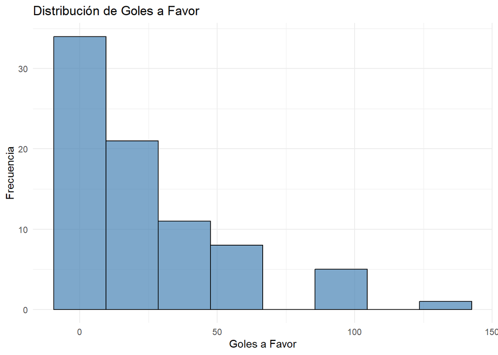

```r
# **Histograma de la variable "goles_favor"**
histograma_goles <- ggplot(datos, aes(x = goles_favor)) +
  geom_histogram(binwidth = 19, fill = "steelblue", color = "black", alpha = 0.7) +
  theme_minimal() +
  labs(title = "Distribución de Goles a Favor", x = "Goles a Favor", y = "Frecuencia")

# Mostrar histograma
print(histograma_goles)
```

### **Tabla de Contingencia**

```r
##Distribución conjunta de las variables

library(janitor)
datos %>%
  tabyl(continente, campeon) %>%
  adorn_totals(where = c("row", "col")) %>%
  adorn_percentages(denominator = "all") #%>%  # cálculo de proporciones
```

|  | continente | campeón | no campeón | Total |
| --- | --- | --- | --- | --- |
| 1 | África | 0.1125 | 0.0250 | 0.1375 |
| 2 | América | 0.1250 | 0.0000 | 0.1250 |
| 3 | Asia | 0.2500 | 0.0625 | 0.3125 |
| 4 | Europa | 0.2250 | 0.0125 | 0.2375 |
| 5 | Oceanía | 0.1625 | 0.0250 | 0.1875 |
| 6 | Total | 0.8750 | 0.1250 | 1.0000 |

```r
  #adorn_pct_formatting(digits = 1)            # mostrarlas como porcentaje (opcional)

  datos %>%
  tabyl(continente, campeon) %>%
  adorn_totals(where = c("row", "col")) %>%
  adorn_percentages(denominator = "all") %>%
  adorn_pct_formatting(digits = 1) %>%
  adorn_ns() %>%
  adorn_title(placement = "top", "Continente", "Campeones del mundo")
```

|  | Campeones del mundo |  |  |
| --- | --- | --- | --- |
| Continente | campeón | no campeón | Total |
| África | 11.2% (9) | 2.5% (2) | 13.8% (11) |
| América | 12.5% (10) | 0.0% (0) | 12.5% (10) |
| Asia | 25.0% (20) | 6.2% (5) | 31.2% (25) |
| Europa | 22.5% (18) | 1.2% (1) | 23.8% (19) |
| Oceanía | 16.2% (13) | 2.5% (2) | 18.8% (15) |
| Total | 87.5% (70) | 12.5% (10) | 100.0% (80) |

# **MEDIDAS DE TENDENCIA CENTRAL, DISPERSIÓN, POSICIÓN, ASIMETRÍA Y CURTOSIS**

## **Medidas de resumen para una variable cuantitativa**

```r
##Para la variable puntos

# Cargar librerías necesarias
library(dplyr)
library(moments)  # Para calcular asimetría y curtosis

# Calcular medidas de tendencia central para una variable ("puntos")
resumen1 <- datos %>%
  summarise(
    media = mean(puntos),                   # Media aritmética
    mediana = median(puntos),               # Mediana
    moda = as.numeric(names(sort(table(puntos), decreasing = TRUE)[1])),  # Moda
  )
# Mostrar resultados
print(resumen1)
```

```
## # A tibble: 1 × 3
##   media mediana  moda
##   <dbl>   <dbl> <dbl>
## 1  66.5    47.5     6
```

```r
# Calcular medidas de variabilidad para una variable ("puntos")

resumen2 <- datos %>%
  summarise(
    media = mean(puntos),                   # Media aritmética
    minimo = min(puntos),                   # Valor mínimo
    maximo = max(puntos),                   # Valor máximo
    rango = maximo - minimo,                # Rango
    varianza = var(puntos),                 # Varianza
    desviacion_estandar = sd(puntos),       # Desviación estándar
    coef_variacion = (desviacion_estandar / media) * 100,  # Coeficiente de variación
  )
# Mostrar resultados
print(resumen2)
```

```
## # A tibble: 1 × 7
##   media minimo maximo rango varianza desviacion_estandar coef_variacion
##   <dbl>  <dbl>  <dbl> <dbl>    <dbl>               <dbl>          <dbl>
## 1  66.5      0    239   239    3451.                58.7           88.4
```

```r
# Calcular el coeficiente de asimetría y curtosis para una variable ("puntos")

resumen3 <- datos %>%
  summarise(
    asimetria = skewness(puntos),           # Coeficiente de asimetría
    curtosis = kurtosis(puntos),            # Curtosis
    n = n()                                 # Número de registros
  )
# Mostrar resultados
print(resumen3)
```

```
## # A tibble: 1 × 3
##   asimetria curtosis     n
##       <dbl>    <dbl> <int>
## 1     0.953     3.06    80
```

```r
# Calcular las medidas de posiciones (cuantiles: cuartiles y percentiles) para
# una variable ("puntos")

library(dplyr)

# Calcular cuartiles y percentiles
resumen4 <- datos %>%
  summarise(
    Q1 = quantile(puntos, 0.25),  # Primer cuartil (25%)
    Q2 = quantile(puntos, 0.50),  # Segundo cuartil (Mediana, 50%)
    Q3 = quantile(puntos, 0.75),  # Tercer cuartil (75%)
    P10 = quantile(puntos, 0.10), # Percentil 10
    P35 = quantile(puntos, 0.35),  # Percentil 35
    P68 = quantile(puntos, 0.68),  # Percentil 68
    P90 = quantile(puntos, 0.90)  # Percentil 90
  )
# Mostrar resultados
print(resumen4)
```

```
## # A tibble: 1 × 7
##      Q1    Q2    Q3   P10   P35   P68   P90
##   <dbl> <dbl> <dbl> <dbl> <dbl> <dbl> <dbl>
## 1  18.5  47.5   100     6    28  86.9  148.
```

## **Medidas de resumen de una variable cuantitativa agrupada por una cualitativa**

```r
##Para la variable cuantitativa puntos y para la variable cualitativa continente

# Cargar librerías necesarias
library(dplyr)
library(moments)  # Para calcular asimetría y curtosis

# Calcular medidas de tendencia central para una variable ("puntos")
datos %>%
  group_by(continente) %>%
  summarise(
    media = mean(puntos),                   # Media aritmética
    mediana = median(puntos),               # Mediana
    moda = as.numeric(names(sort(table(puntos), decreasing = TRUE)[1])),  # Moda
)
```

| continente | media | mediana | moda |
| --- | --- | --- | --- |
| América | 77.80000 | 66 | 5 |
| Asia | 67.04000 | 63 | 3 |
| Europa | 62.47368 | 47 | 0 |
| Oceanía | 74.80000 | 48 | 140 |
| África | 50.36364 | 27 | 10 |

```r
# Calcular medidas de variabilidad para una variable ("puntos")

datos %>%
  group_by(continente) %>%
  summarise(
    media = mean(puntos),                   # Media aritmética
    minimo = min(puntos),                   # Valor mínimo
    maximo = max(puntos),                   # Valor máximo
    rango = maximo - minimo,                # Rango
    varianza = var(puntos),                 # Varianza
    desviacion_estandar = sd(puntos),       # Desviación estándar
    coef_variacion = (desviacion_estandar / media) * 100,  # Coeficiente de variación
)
```

| continente | media | minimo | maximo | rango | varianza | desviacion_estandar | coef_variacion |
| --- | --- | --- | --- | --- | --- | --- | --- |
| América | 77.80000 | 5 | 196 | 191 | 3791.289 | 61.57344 | 79.14324 |
| Asia | 67.04000 | 3 | 239 | 236 | 3249.373 | 57.00327 | 85.02875 |
| Europa | 62.47368 | 0 | 191 | 191 | 3397.708 | 58.28986 | 93.30306 |
| Oceanía | 74.80000 | 2 | 195 | 193 | 4209.171 | 64.87813 | 86.73546 |
| África | 50.36364 | 6 | 174 | 168 | 3496.055 | 59.12744 | 117.40106 |

```r
# Calcular el coeficiente de asimetría y curtosis para una variable ("puntos")

datos %>%
  group_by(continente) %>%
  summarise(
    asimetria = skewness(puntos),           # Coeficiente de asimetría
    curtosis = kurtosis(puntos),            # Curtosis
    n = n()                                 # Número de registros
)
```

| continente | asimetria | curtosis | n |
| --- | --- | --- | --- |
| América | 0.6135281 | 2.301449 | 10 |
| Asia | 1.3349646 | 4.766949 | 25 |
| Europa | 0.9644922 | 3.056601 | 19 |
| Oceanía | 0.5874195 | 1.948163 | 15 |
| África | 1.1600300 | 2.820564 | 11 |

```r
# Calcular las medidas de posiciones (cuantiles: cuartiles y percentiles) para
# una variable ("puntos")

library(dplyr)

# Calcular cuartiles y percentiles
datos %>%
  group_by(continente) %>%
  summarise(
    Q1 = quantile(puntos, 0.25),  # Primer cuartil (25%)
    Q2 = quantile(puntos, 0.50),  # Segundo cuartil (Mediana, 50%)
    Q3 = quantile(puntos, 0.75),  # Tercer cuartil (75%)
    P10 = quantile(puntos, 0.10), # Percentil 10
    P35 = quantile(puntos, 0.35),  # Percentil 35
    P68 = quantile(puntos, 0.68),  # Percentil 68
    P90 = quantile(puntos, 0.90)  # Percentil 90
)
```

| continente | Q1 | Q2 | Q3 | P10 | P35 | P68 | P90 |
| --- | --- | --- | --- | --- | --- | --- | --- |
| América | 33.5 | 66 | 111.75 | 15.8 | 41.45 | 96.00 | 150.1 |
| Asia | 25.0 | 63 | 99.00 | 8.0 | 34.40 | 70.00 | 126.2 |
| Europa | 14.0 | 47 | 87.50 | 5.8 | 23.10 | 80.20 | 138.4 |
| Oceanía | 26.5 | 48 | 128.50 | 6.8 | 38.00 | 108.84 | 163.4 |
| África | 10.0 | 27 | 71.50 | 8.0 | 10.00 | 41.60 | 138.0 |

### **Diagrama de cajas de una variable cuantitativa agrupada por una cualitativa**

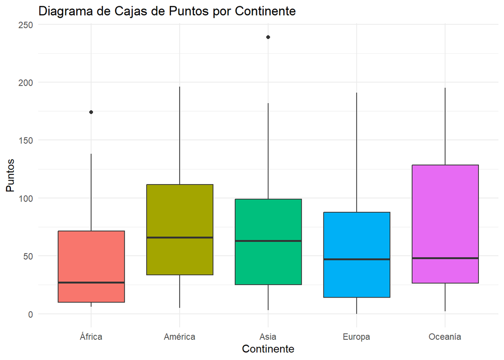

```r
# Cargar librerías necesarias
library(ggplot2)

# Crear el diagrama de cajas agrupado
ggplot(datos, aes(x = continente, y = puntos, fill = continente)) +
  geom_boxplot() +
  labs(title = "Diagrama de Cajas de Puntos por Continente",
       x = "Continente",
       y = "Puntos") +
  theme_minimal() +
  theme(legend.position = "none")  # Oculta la leyenda, ya que los colores son por continente
```